# Physically Hazardous Asteroid Prediction

## Phase 1 - Data Cleaning and Normalization

```python
import numpy as np
import pandas as pd
import matplotlib.pyplot as plt
import seaborn as sns
import matplotlib
%matplotlib inline
```

### Dataset

The dataset being used for this agent is a subset of data taken from the NASA NEO database. This particular subset of data is noted as being well-maintained and clean, but also contains a relatively small number of datapoints. There are other datasets that will require a fair bit more cleaning but also contain vastly more datapoints that could be used as an alternative should the initial dataset prove to be insufficient.

```python
#loading dataset, source: https://www.kaggle.com/datasets/lovishbansal123/nasa-asteroids-classification
df = pd.read_csv('./nasa.csv')

#checking data shape
print("Number of Datapoints: " + str(df.shape[0]))
print("Number of Features: " + str(df.shape[1]))
```

```
Number of Datapoints: 4687
Number of Features: 40
```

```python
#examining dataset
df.head()
```

|  | Neo Reference ID | Name | Absolute Magnitude | Est Dia in KM(min) | Est Dia in KM(max) | Est Dia in M(min) | Est Dia in M(max) | Est Dia in Miles(min) | Est Dia in Miles(max) | Est Dia in Feet(min) | ... | Asc Node Longitude | Orbital Period | Perihelion Distance | Perihelion Arg | Aphelion Dist | Perihelion Time | Mean Anomaly | Mean Motion | Equinox | Hazardous |
| --- | --- | --- | --- | --- | --- | --- | --- | --- | --- | --- | --- | --- | --- | --- | --- | --- | --- | --- | --- | --- | --- |
| 0 | 3703080 | 3703080 | 21.6 | 0.127220 | 0.284472 | 127.219879 | 284.472297 | 0.079051 | 0.176763 | 417.388066 | ... | 314.373913 | 609.599786 | 0.808259 | 57.257470 | 2.005764 | 2.458162e+06 | 264.837533 | 0.590551 | J2000 | True |
| 1 | 3723955 | 3723955 | 21.3 | 0.146068 | 0.326618 | 146.067964 | 326.617897 | 0.090762 | 0.202951 | 479.225620 | ... | 136.717242 | 425.869294 | 0.718200 | 313.091975 | 1.497352 | 2.457795e+06 | 173.741112 | 0.845330 | J2000 | False |
| 2 | 2446862 | 2446862 | 20.3 | 0.231502 | 0.517654 | 231.502122 | 517.654482 | 0.143849 | 0.321655 | 759.521423 | ... | 259.475979 | 643.580228 | 0.950791 | 248.415038 | 1.966857 | 2.458120e+06 | 292.893654 | 0.559371 | J2000 | True |
| 3 | 3092506 | 3092506 | 27.4 | 0.008801 | 0.019681 | 8.801465 | 19.680675 | 0.005469 | 0.012229 | 28.876199 | ... | 57.173266 | 514.082140 | 0.983902 | 18.707701 | 1.527904 | 2.457902e+06 | 68.741007 | 0.700277 | J2000 | False |
| 4 | 3514799 | 3514799 | 21.6 | 0.127220 | 0.284472 | 127.219879 | 284.472297 | 0.079051 | 0.176763 | 417.388066 | ... | 84.629307 | 495.597821 | 0.967687 | 158.263596 | 1.483543 | 2.457814e+06 | 135.142133 | 0.726395 | J2000 | True |

5 rows × 40 columns

```python
#checking data for null values
df.isna().sum()
```

```
Neo Reference ID                0
Name                            0
Absolute Magnitude              0
Est Dia in KM(min)              0
Est Dia in KM(max)              0
Est Dia in M(min)               0
Est Dia in M(max)               0
Est Dia in Miles(min)           0
Est Dia in Miles(max)           0
Est Dia in Feet(min)            0
Est Dia in Feet(max)            0
Close Approach Date             0
Epoch Date Close Approach       0
Relative Velocity km per sec    0
Relative Velocity km per hr     0
Miles per hour                  0
Miss Dist.(Astronomical)        0
Miss Dist.(lunar)               0
Miss Dist.(kilometers)          0
Miss Dist.(miles)               0
Orbiting Body                   0
Orbit ID                        0
Orbit Determination Date        0
Orbit Uncertainity              0
Minimum Orbit Intersection      0
Jupiter Tisserand Invariant     0
Epoch Osculation                0
Eccentricity                    0
Semi Major Axis                 0
Inclination                     0
Asc Node Longitude              0
Orbital Period                  0
Perihelion Distance             0
Perihelion Arg                  0
Aphelion Dist                   0
Perihelion Time                 0
Mean Anomaly                    0
Mean Motion                     0
Equinox                         0
Hazardous                       0
dtype: int64
```

```python
#NOTE: Review the NEO glossary definitions and determine if any additional columns can be dropped from the dataset;
#some of these may be unnecessary in determining classification or even just redundant, be sure to note any extra columns that
#are being dropped and why, can document in more detail in the report as necessary. May also be a good idea to reorganize the
#cells so that columns that are being dropped get dropped before visuals, and another reiteration of the shape of final data set
#including features and such afterward
```

```python
#examining data types
df.info()
```

```
<class 'pandas.core.frame.DataFrame'>
RangeIndex: 4687 entries, 0 to 4686
Data columns (total 40 columns):
 #   Column                        Non-Null Count  Dtype
---  ------                        --------------  -----
 0   Neo Reference ID              4687 non-null   int64
 1   Name                          4687 non-null   int64
 2   Absolute Magnitude            4687 non-null   float64
 3   Est Dia in KM(min)            4687 non-null   float64
 4   Est Dia in KM(max)            4687 non-null   float64
 5   Est Dia in M(min)             4687 non-null   float64
 6   Est Dia in M(max)             4687 non-null   float64
 7   Est Dia in Miles(min)         4687 non-null   float64
 8   Est Dia in Miles(max)         4687 non-null   float64
 9   Est Dia in Feet(min)          4687 non-null   float64
```

[output cut: 32 more lines]

### Data Preparation

The 'name' and 'Neo Reference ID' columns will likely be dropped as they are used to identify objects but don't necessarily have any bearing on the determination of an asteroid. Along with these, the 'Close Approach Date', 'Orbiting Body', 'Orbit Determination Date', and 'Equinox' columns will be removed, because these non-numeric data types are difficult to process and are not listed among the determining factors in a PHA.

```python
df.drop(['Neo Reference ID', 'Name', 'Close Approach Date', 'Orbiting Body',
         'Orbit Determination Date', 'Equinox'], axis=1, inplace=True)
```

Several columns contain data that is essentially redundant, i.e. 'Est Dia in KM(max)' versus 'Est Dia in Miles(min)'. For the sake of reducing the number of features in the dataset, some of the redundant columns will be removed, favoring measurements using the metric system and smaller units of measurement.

```python
df.drop(['Est Dia in KM(min)', 'Est Dia in KM(max)', 'Est Dia in Miles(min)', 'Est Dia in Miles(max)',
        'Est Dia in Feet(min)', 'Est Dia in Feet(max)', 'Relative Velocity km per hr',
        'Miles per hour', 'Miss Dist.(miles)', 'Miss Dist.(lunar)', 'Miss Dist.(Astronomical)'], axis=1, inplace=True)
```

The output label is currently a boolean data type. We will change the output label to a numeric data type.

```python
df['Hazardous'] = df['Hazardous'].astype(int)
```

#### Final Dataset Shape

```python
#verifying final counts of rows and columns
print("Number of Datapoints: " + str(df.shape[0]))
print("Number of Features: " + str(df.shape[1]))
```

```
Number of Datapoints: 4687
Number of Features: 23
```

### Examining Dataset Features

```python
df.describe()
```

|  | Absolute Magnitude | Est Dia in M(min) | Est Dia in M(max) | Epoch Date Close Approach | Relative Velocity km per sec | Miss Dist.(kilometers) | Orbit ID | Orbit Uncertainity | Minimum Orbit Intersection | Jupiter Tisserand Invariant | ... | Inclination | Asc Node Longitude | Orbital Period | Perihelion Distance | Perihelion Arg | Aphelion Dist | Perihelion Time | Mean Anomaly | Mean Motion | Hazardous |
| --- | --- | --- | --- | --- | --- | --- | --- | --- | --- | --- | --- | --- | --- | --- | --- | --- | --- | --- | --- | --- | --- |
| count | 4687.000000 | 4687.000000 | 4687.000000 | 4.687000e+03 | 4687.000000 | 4.687000e+03 | 4687.000000 | 4687.000000 | 4687.000000 | 4687.000000 | ... | 4687.000000 | 4687.000000 | 4687.000000 | 4687.000000 | 4687.000000 | 4687.000000 | 4.687000e+03 | 4687.000000 | 4687.000000 | 4687.000000 |
| mean | 22.267865 | 204.604203 | 457.508906 | 1.179881e+12 | 13.970811 | 3.841347e+07 | 28.300619 | 3.516962 | 0.082320 | 5.056111 | ... | 13.373844 | 172.157275 | 635.582076 | 0.813383 | 183.932151 | 1.987144 | 2.457728e+06 | 181.167927 | 0.738242 | 0.161084 |
| std | 2.890972 | 369.573402 | 826.391249 | 1.981540e+11 | 7.293223 | 2.181110e+07 | 38.299668 | 3.078307 | 0.090300 | 1.237818 | ... | 10.936227 | 103.276777 | 370.954727 | 0.242059 | 103.513035 | 0.951519 | 9.442264e+02 | 107.501623 | 0.342627 | 0.367647 |
| min | 11.160000 | 1.010543 | 2.259644 | 7.889472e+11 | 0.335504 | 2.660989e+04 | 1.000000 | 0.000000 | 0.000002 | 2.196000 | ... | 0.014513 | 0.001941 | 176.557161 | 0.080744 | 0.006918 | 0.803765 | 2.450100e+06 | 0.003191 | 0.086285 | 0.000000 |
| 25% | 20.100000 | 33.462237 | 74.823838 | 1.015574e+12 | 8.432865 | 1.995928e+07 | 9.000000 | 0.000000 | 0.014585 | 4.049500 | ... | 4.962341 | 83.081208 | 365.605031 | 0.630834 | 95.625916 | 1.266059 | 2.457815e+06 | 87.006918 | 0.453289 | 0.000000 |
| 50% | 21.900000 | 110.803882 | 247.765013 | 1.203062e+12 | 12.917889 | 3.964771e+07 | 16.000000 | 3.000000 | 0.047365 | 5.071000 | ... | 10.311836 | 172.625393 | 504.947292 | 0.833153 | 189.761641 | 1.618195 | 2.457973e+06 | 185.718889 | 0.712946 | 0.000000 |
| 75% | 24.500000 | 253.837029 | 567.596853 | 1.355558e+12 | 18.077649 | 5.746863e+07 | 31.000000 | 6.000000 | 0.123593 | 6.019000 | ... | 19.511681 | 255.026909 | 794.195972 | 0.997227 | 271.777557 | 2.451171 | 2.458108e+06 | 276.531946 | 0.984669 | 0.000000 |
| max | 32.100000 | 15579.552413 | 34836.938254 | 1.473318e+12 | 44.633747 | 7.478160e+07 | 611.000000 | 9.000000 | 0.477891 | 9.025000 | ... | 75.406667 | 359.905890 | 4172.231343 | 1.299832 | 359.993098 | 8.983852 | 2.458839e+06 | 359.917991 | 2.039000 | 1.000000 |

8 rows × 23 columns

### Feature Correlation

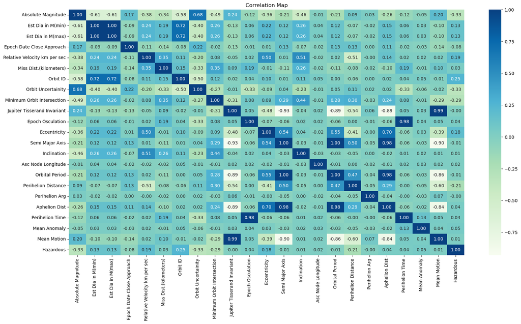

```python
plt.figure(figsize = (20, 10))
sns.heatmap(df.corr(), cmap='GnBu', annot=True, fmt='.2f')
plt.title('Correlation Map')
plt.show()
```

### Distribution of Input Features

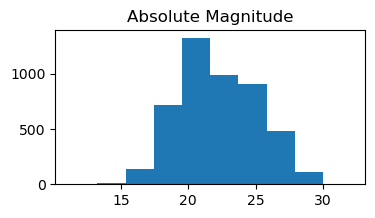

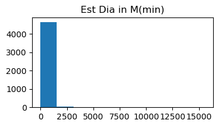

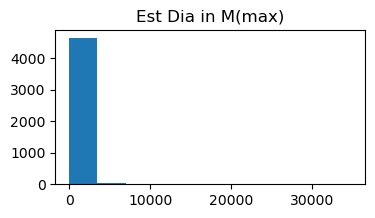

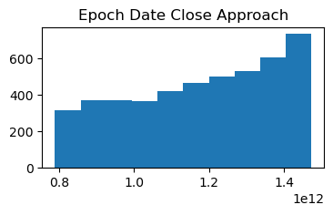

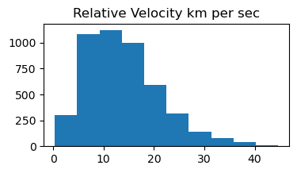

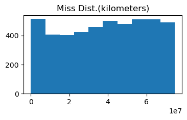

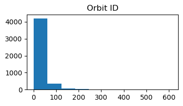

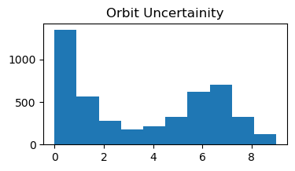

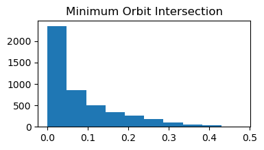

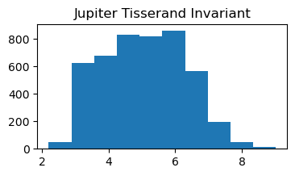

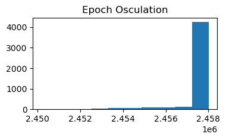

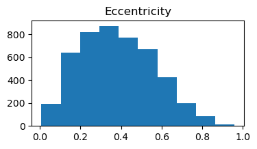

[10 more figures not shown]

```python
input_features = ['Absolute Magnitude', 'Est Dia in M(min)', 'Est Dia in M(max)', 'Epoch Date Close Approach',
                 'Relative Velocity km per sec', 'Miss Dist.(kilometers)', 'Orbit ID', 'Orbit Uncertainity',
                 'Minimum Orbit Intersection', 'Jupiter Tisserand Invariant', 'Epoch Osculation', 'Eccentricity',
                 'Semi Major Axis', 'Inclination', 'Asc Node Longitude', 'Orbital Period', 'Perihelion Distance',
                 'Perihelion Arg', 'Aphelion Dist', 'Perihelion Time', 'Mean Anomaly', 'Mean Motion']

for feature in input_features:
    plt.figure(figsize = (4,2))
    plt.hist(df[feature])
    plt.title(feature)
    plt.show()
```

### Distribution of Output Label

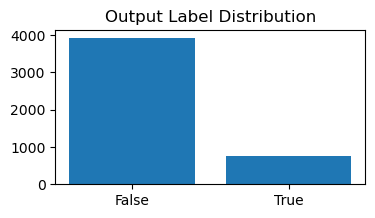

```python
#getting label names and category counts
labels = ['False', 'True']
l_counts = [df['Hazardous'].value_counts()[0], df['Hazardous'].value_counts()[1]]

#plotting distribution of output labels as bar chart
plt.figure(figsize=(4,2))
plt.bar(labels, l_counts)
plt.title('Output Label Distribution')
plt.show()
```

Output label is skewed with significantly more values of 0 (False) than 1 (true). It may be necessary to use a sampling technique.

### Data Normalization

#### Data Normalization should be done AFTER data is split into training and testing datasets and ONLY on training dataset.

```python
# Mean normalization
min = df.min(axis = 0)
max = df.max(axis = 0)
mean = df.mean(axis = 0)
df_norm = (df - mean) / (max - min)
```

#### Checking Normalized Data

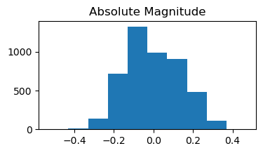

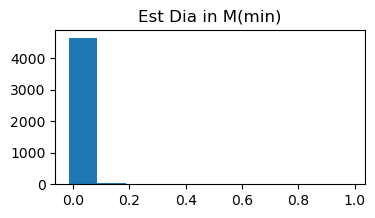

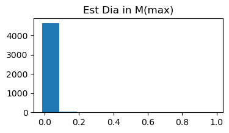

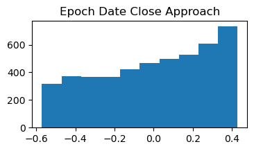

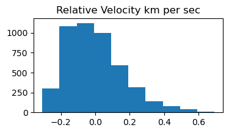

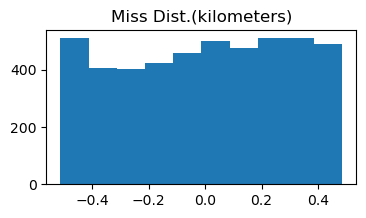

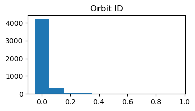

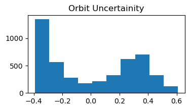

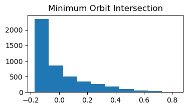

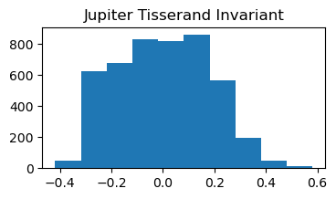

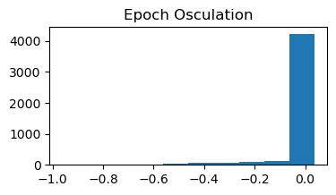

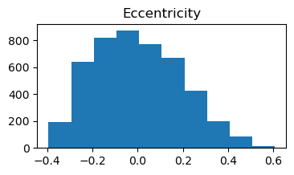

[10 more figures not shown]

```python
for feature in input_features:
    plt.figure(figsize = (4,2))
    plt.hist(df_norm[feature])
    plt.title(feature)
    plt.show()
```